# R Notebook

```r
# Read in the data
hrdata <- read.csv("HR-Employee-Attrition.csv")
```

```r
dim(hrdata)
```

```
[1] 1470   35
```

```r
df_left <- hrdata[c("Attrition", "MonthlyIncome", "Gender", "JobRole", "PercentSalaryHike", "YearsAtCompany", "YearsInCurrentRole","YearsSinceLastPromotion", "YearsWithCurrManager", "DistanceFromHome")]
df_left_yes <- df_left[df_left$Attrition == "Yes",]
df_left_yes
```

|  | Attrition | MonthlyIncome | Gender | JobRole | PercentSalaryHike | YearsAtCompany | YearsInCurrentRole | YearsSinceLastPromotion | YearsWithCurrManager | DistanceFromHome |
| --- | --- | --- | --- | --- | --- | --- | --- | --- | --- | --- |
| 1 | Yes | 5993 | Female | Sales Executive | 11 | 6 | 4 | 0 | 5 | 1 |
| 3 | Yes | 2090 | Male | Laboratory Technician | 15 | 0 | 0 | 0 | 0 | 2 |
| 15 | Yes | 2028 | Male | Laboratory Technician | 14 | 4 | 2 | 0 | 3 | 24 |
| 22 | Yes | 3407 | Male | Sales Representative | 23 | 5 | 3 | 0 | 3 | 9 |
| 25 | Yes | 2960 | Male | Research Scientist | 11 | 4 | 2 | 1 | 3 | 6 |
| 27 | Yes | 3919 | Female | Research Scientist | 22 | 10 | 2 | 6 | 7 | 16 |
| 34 | Yes | 2086 | Male | Sales Representative | 14 | 1 | 0 | 0 | 0 | 5 |
| 35 | Yes | 2293 | Male | Research Scientist | 16 | 2 | 0 | 2 | 0 | 1 |
| 37 | Yes | 2683 | Male | Sales Representative | 14 | 3 | 2 | 0 | 2 | 3 |
| 43 | Yes | 2293 | Male | Laboratory Technician | 12 | 1 | 0 | 0 | 1 | 25 |

[output cut: 227 more lines]

```r
install.packages('writexl')
```

```
Error in install.packages : Updating loaded packages
```

```r
library(writexl)

write_xlsx(df_left_yes, 'C:\\Users\\jfauxinu\\Documents\\hr_analysis_module8\\data.xlsx')
```

```r
# correlation matrix for selected columns to see if the demographics correlate
cor(
hrdata[ , c("Age", "DailyRate", "DistanceFromHome", "Education", "HourlyRate", "MonthlyIncome", "MonthlyRate", "NumCompaniesWorked", "TotalWorkingYears", "TrainingTimesLastYear")]
)
```

```
                              Age    DailyRate DistanceFromHome   Education   HourlyRate MonthlyIncome  MonthlyRate NumCompaniesWorked
Age                    1.00000000  0.010660943     -0.001686120  0.20803373  0.024286543   0.497854567  0.028051167         0.29963476
DailyRate              0.01066094  1.000000000     -0.004985337 -0.01680643  0.023381422   0.007707059 -0.032181602         0.03815343
DistanceFromHome      -0.00168612 -0.004985337      1.000000000  0.02104183  0.031130586  -0.017014445  0.027472864        -0.02925080
Education              0.20803373 -0.016806433      0.021041826  1.00000000  0.016774829   0.094960677 -0.026084197         0.12631656
HourlyRate             0.02428654  0.023381422      0.031130586  0.01677483  1.000000000  -0.015794304 -0.015296750         0.02215688
MonthlyIncome          0.49785457  0.007707059     -0.017014445  0.09496068 -0.015794304   1.000000000  0.034813626         0.14951522
MonthlyRate            0.02805117 -0.032181602      0.027472864 -0.02608420 -0.015296750   0.034813626  1.000000000         0.01752135
NumCompaniesWorked     0.29963476  0.038153434     -0.029250804  0.12631656  0.022156883   0.149515216  0.017521353         1.00000000
TotalWorkingYears      0.68038054  0.014514739      0.004628426  0.14827970 -0.002333682   0.772893246  0.026442471         0.23763859
TrainingTimesLastYear -0.01962082  0.002452543     -0.036942234 -0.02510024 -0.008547685  -0.021736277  0.001466881        -0.06605407
                      TotalWorkingYears TrainingTimesLastYear
Age                         0.680380536          -0.019620819
DailyRate                   0.014514739           0.002452543
DistanceFromHome            0.004628426          -0.036942234
Education                   0.148279697          -0.025100241
HourlyRate                 -0.002333682          -0.008547685
MonthlyIncome               0.772893246          -0.021736277
MonthlyRate                 0.026442471           0.001466881
NumCompaniesWorked          0.237638590          -0.066054072
TotalWorkingYears           1.000000000          -0.035661571
TrainingTimesLastYear      -0.035661571           1.000000000
```

#### Strong positive correlation

##### Monthly Income and Total Working Years has a .77 correlation - more years worked more monthly income earned

##### Age and Total Working Years has a .68 correlation - more years worked employees are older

##### Age and Monthly Income has a .5 correlation - generally the older people are the more their monthly income

#### Positive correlation

##### Age and NumberCompaniesWorked has a .30 correlation

##### Age and Education has a .21

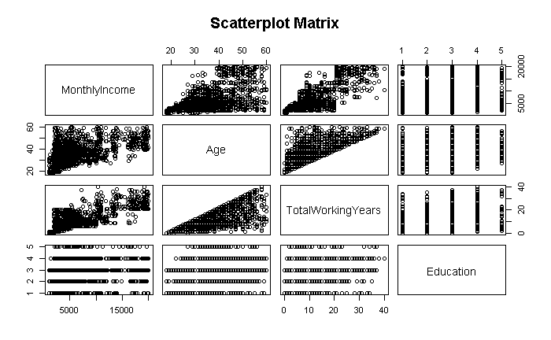

```r
pairs(~MonthlyIncome+Age+TotalWorkingYears+Education,data = hrdata,
main = "Scatterplot Matrix")
```

#### Strong positive correlation

##### Monthly Income and Total Working Years

##### Age and Total Working Years

```r
# Install  packages - only have to do this once
#install.packages("ggplot2")
#install.packages("GGally")

# Load ggplot2
library("ggplot2")
```

```r
# Load GGally
library(GGally)
```

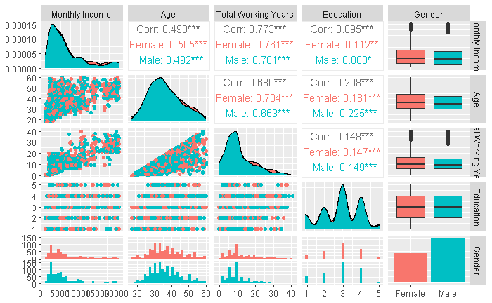

```r
# add Gender to see the correlations
ggpairs(hrdata, columns = c('MonthlyIncome', 'Age', 'TotalWorkingYears', 'Education', 'Gender'),
        aes(color = Gender),
        columnLabels = c("Monthly Income", "Age", "Total Working Years", "Education", "Gender"))
```

#### Strong positive correlation

##### Age and Monthly Income has a .498 correlation - generally the older people are the more their monthly income

#### Female has a .505 correlation - females are slightly older

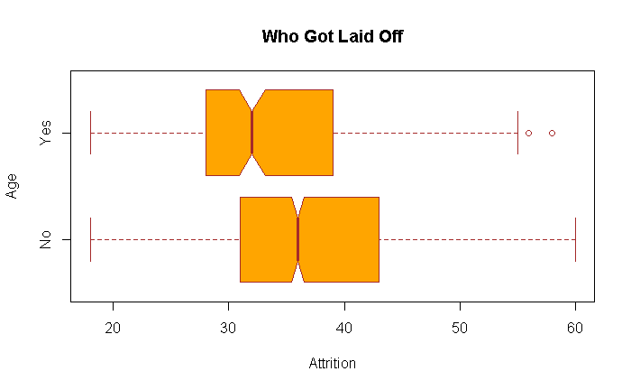

```r
# boxplot of the age distribution of employees who were laid off (yes) and those who were not (no)
boxplot(Age~Attrition,data=hrdata, main= "Who Got Laid Off", xlab="Attrition", ylab="Age",
        col = "orange", border = "brown", horizontal = TRUE, notch = TRUE)
```

```r
yes_age <- hrdata[(hrdata$Attrition == "Yes"),'Age']
no_age <- hrdata[(hrdata$Attrition != "Yes"),'Age']
```

```r
t.test(yes_age, no_age)
```

```
    Welch Two Sample t-test

data:  yes_age and no_age
t = -5.828, df = 316.93, p-value = 1.38e-08
alternative hypothesis: true difference in means is not equal to 0
95 percent confidence interval:
 -5.288346 -2.618930
sample estimates:
mean of x mean of y
 33.60759  37.56123
```

Assigned to investigate claim that the last layoffs impacted older employees - age discrimination The p value is less than 0.05, there is a statistically significant difference between the two samples, but employees that were affected were actually younger than those who remained on the job.

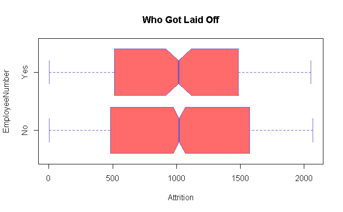

```r
# boxplot of the employee number distribution of employees who were laid off
boxplot(EmployeeNumber~Attrition,data=hrdata, main= "Who Got Laid Off", xlab="Attrition", ylab="EmployeeNumber",
        col = "indianred1", border = "slateblue", horizontal = TRUE, notch = TRUE)
```

From the boxplot it seems some newer hires were not impacted, but on tail end it seems the numbers were smaller.

```r
yes_emp_num <- hrdata[(hrdata$Attrition == "Yes"),'EmployeeNumber']
no_emp_num <- hrdata[(hrdata$Attrition != "Yes"),'EmployeeNumber']
```

```r
t.test(yes_emp_num, no_emp_num)
```

```
    Welch Two Sample t-test

data:  yes_emp_num and no_emp_num
t = -0.41725, df = 342.33, p-value = 0.6768
alternative hypothesis: true difference in means is not equal to 0
95 percent confidence interval:
 -98.91087  64.29061
sample estimates:
mean of x mean of y
 1010.346  1027.656
```

Another claim has been filed - this time need to investigate if recently hired employees were impacted more than senior employees. This time the p value is much larger than 0.05. Employee Number does not have a statistically significant relationship with the Attrition. Can’t say with confidence that newer employees were impacted more than senior employees.

```r
model1 = lm(MonthlyIncome ~ Age, data = hrdata)
summary(model1)
```

```
Call:
lm(formula = MonthlyIncome ~ Age, data = hrdata)

Residuals:
    Min      1Q  Median      3Q     Max
-9990.1 -2592.7  -677.9  1810.5 12540.8

Coefficients:
            Estimate Std. Error t value Pr(>|t|)
(Intercept) -2970.67     443.70  -6.695 3.06e-11 ***
Age           256.57      11.67  21.995  < 2e-16 ***
---
Signif. codes:  0 ‘***’ 0.001 ‘**’ 0.01 ‘*’ 0.05 ‘.’ 0.1 ‘ ’ 1

Residual standard error: 4084 on 1468 degrees of freedom
Multiple R-squared:  0.2479,    Adjusted R-squared:  0.2473
F-statistic: 483.8 on 1 and 1468 DF,  p-value: < 2.2e-16
```

#### Linear regression model that predicts the MonthlyIncome based upon Age

#### p is smaller than 0.05, which is statistically signifcant.

#### The R-squared value is .2479, the model explains

#### close to 25% of variance in the MonthlyIncome is due to age.

```r
model2 = lm(MonthlyIncome ~ Age + TotalWorkingYears, data = hrdata)
summary(model2)
```

```
Call:
lm(formula = MonthlyIncome ~ Age + TotalWorkingYears, data = hrdata)

Residuals:
     Min       1Q   Median       3Q      Max
-11310.8  -1690.8    -91.4   1428.3  11461.5

Coefficients:
                  Estimate Std. Error t value Pr(>|t|)
(Intercept)        1978.08     352.36   5.614 2.36e-08 ***
Age                 -26.87      11.63  -2.311    0.021 *
TotalWorkingYears   489.13      13.65  35.824  < 2e-16 ***
---
Signif. codes:  0 ‘***’ 0.001 ‘**’ 0.01 ‘*’ 0.05 ‘.’ 0.1 ‘ ’ 1

Residual standard error: 2984 on 1467 degrees of freedom
Multiple R-squared:  0.5988,    Adjusted R-squared:  0.5983
F-statistic:  1095 on 2 and 1467 DF,  p-value: < 2.2e-16
```

### The p-value is still smaller than 0.05. The R-squared value is increaded to 0.5988,

### so model2 explains that close to 60% of the variance in the MonthlyIncome

### and TotalWorkingYears by due to using the age variable.

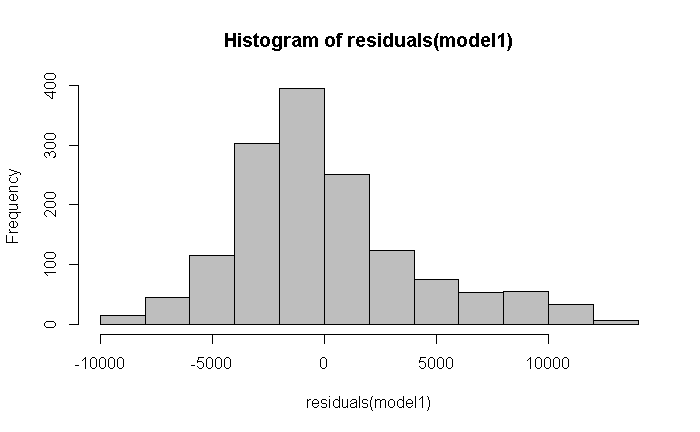

```r
hist(residuals(model1), col = "gray")
```

### Checking Assumptions of the Model

#### The distribution of model residuals should be approximately normal.

### Above the distribution is slightly right skewed.

### Belwo the distribution is normal

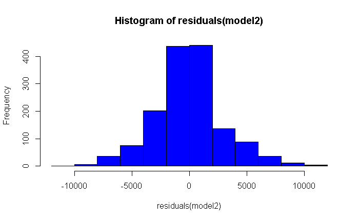

```r
hist(residuals(model2), col = "blue")
```

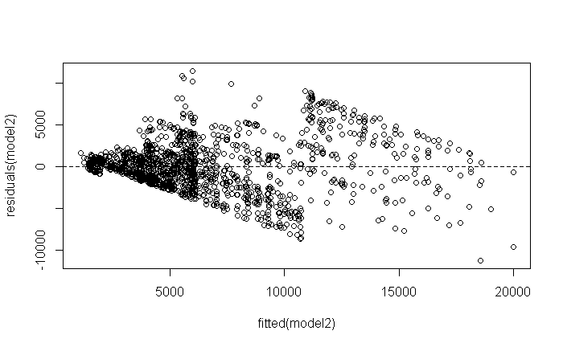

```r
#create fitted value vs residual plot
plot(fitted(model2), residuals(model2))

#add horizontal line at 0
abline(h = 0, lty = 2)
```

The variance of the residuals should be consistent for all observations.